# Web Traffic Forecasting

## 1. Data Exploration

### 1.1 Import Libraries

```python
import numpy as np # linear algebra
import pandas as pd # data processing, CSV file I/O (e.g. pd.read_csv)
from pandas import read_csv, datetime, Series

from pandas.plotting import autocorrelation_plot

import os
import matplotlib.pyplot as plt
from matplotlib import pyplot
import re
from math import sqrt
%matplotlib inline


from sklearn.metrics import mean_squared_error, r2_score, median_absolute_error, mean_absolute_error
import statsmodels.api as sm
from statsmodels.tsa.arima_process import arma_generate_sample
from statsmodels.tsa.stattools import adfuller
from statsmodels.graphics.tsaplots import plot_acf, plot_pacf

from pyramid.arima import auto_arima

from __future__ import print_function

np.random.seed(12345)

print(os.listdir("./"))
```

```
['.ipynb_checkpoints', '99_plot_arima.ipynb', 'all', 'Arima-WebTrafficExploration-ARIMA.ipynb', 'data', 'io_plot_arima.ipynb', 'pics', 'pll_plot_arima.ipynb', 'ws_plot_arima.ipynb']
```

### 1.2 Import Data

```python
df = pd.read_csv('./all/processed.csv').fillna(0)
print("Number of wiki pages is",df.shape[0]) #gives number of row count
print("Number of days is",df.shape[1]) #gives number of col count
```

```
Number of wiki pages is 145063
Number of days is 557
```

- PageName: Page Name
- Lang: Page Language
- Project: Wikipedia project (e.g. wikipedia, wikimedia etc)
- Access: type of access (e.g. desktop)
- Agent: type of agent (e.g. spider).
- Page: contains all the information together. In other words, each article name has the following format: 'name_project_access_agent' (e.g. 'AKB48_zh.wikipedia.org_all-access_spider').

### 1.3. Data cleaning: daily views of individual pages

We randomly sample 100 wiki pages and organize them in order of the mean views. The idea is to make prediction for pages which have more number of views.

```python
df['Avg'] = df.iloc[:,2:-6].mean(axis=1)
dfs = df.sample(n=100, random_state=2)
dfs = dfs.drop(['Unnamed: 0','PageName','Access', 'Agent', 'Avg','Lang','Project'],axis = 1) #drop coulumns
dfs.set_index('Page', inplace=True)
dfs = dfs.T
dfs = dfs.reindex(dfs.mean().sort_values().index, axis=1) #ascending order of column mean
dfs.describe()
dfs.to_csv('C:\ML Projects\WebTrafficPrediction\FinalCodeforWebsite\data\dfs.csv')
```

```python
dfs.head()
```

| Page | 恶魔少爷别吻我_zh.wikipedia.org_all-access_spider | User:Anasserrihani_commons.wikimedia.org_all-access_spider | User:Rxy_www.mediawiki.org_mobile-web_all-agents | Manual:Installation_guide/en-gb_www.mediawiki.org_mobile-web_all-agents | Boreczek,_Masovian_Voivodeship_en.wikipedia.org_all-access_all-agents | Gustavo_Gaviria_fr.wikipedia.org_all-access_spider | Extension:HTML5video_www.mediawiki.org_all-access_spider | Julia_Piaton_fr.wikipedia.org_all-access_spider | Special:MyLanguage/Manual:MediaWiki_feature_list_www.mediawiki.org_mobile-web_all-agents | Commons:Wiki_Loves_Monuments_2016_in_the_United_States/Washington_commons.wikimedia.org_desktop_all-agents | ... | 田口智治_ja.wikipedia.org_all-access_all-agents | Internet_Movie_Database_de.wikipedia.org_all-access_all-agents | Wikipedia_en_español_es.wikipedia.org_all-access_all-agents | Deepwater_Horizon_oil_spill_en.wikipedia.org_all-access_all-agents | 安倍晋三_ja.wikipedia.org_all-access_all-agents | William_Shakespeare_es.wikipedia.org_all-access_all-agents | Teenage_Mutant_Ninja_Turtles_en.wikipedia.org_mobile-web_all-agents | Pretty_Little_Liars_(TV_series)_en.wikipedia.org_mobile-web_all-agents | Inside_Out_(2015_film)_en.wikipedia.org_desktop_all-agents | 真田丸_(NHK大河ドラマ)_ja.wikipedia.org_all-access_all-agents |
| --- | --- | --- | --- | --- | --- | --- | --- | --- | --- | --- | --- | --- | --- | --- | --- | --- | --- | --- | --- | --- | --- |
| 2015-07-01 | 0.0 | 0.0 | 0.0 | 5.0 | 3.0 | 0.0 | 2.0 | 1.0 | 0.0 | 0.0 | ... | 34.0 | 2468.0 | 2959.0 | 1778.0 | 3232.0 | 3791.0 | 4342.0 | 18883.0 | 28057.0 | 1621.0 |
| 2015-07-02 | 0.0 | 0.0 | 0.0 | 3.0 | 2.0 | 0.0 | 0.0 | 2.0 | 0.0 | 0.0 | ... | 1285359.0 | 2528.0 | 2807.0 | 7837.0 | 3196.0 | 4016.0 | 5130.0 | 12115.0 | 23235.0 | 1525.0 |
| 2015-07-03 | 0.0 | 0.0 | 0.0 | 2.0 | 1.0 | 0.0 | 0.0 | 2.0 | 0.0 | 0.0 | ... | 48831.0 | 2585.0 | 2597.0 | 5100.0 | 7302.0 | 3045.0 | 5279.0 | 10309.0 | 22578.0 | 1719.0 |
| 2015-07-04 | 0.0 | 0.0 | 0.0 | 8.0 | 3.0 | 0.0 | 2.0 | 1.0 | 0.0 | 0.0 | ... | 9121.0 | 2594.0 | 2105.0 | 2005.0 | 4107.0 | 2153.0 | 5748.0 | 10576.0 | 23825.0 | 2351.0 |
| 2015-07-05 | 0.0 | 0.0 | 0.0 | 4.0 | 3.0 | 0.0 | 0.0 | 3.0 | 0.0 | 0.0 | ... | 4165.0 | 3222.0 | 2294.0 | 1745.0 | 3598.0 | 2533.0 | 6584.0 | 10965.0 | 24725.0 | 3271.0 |

5 rows × 100 columns

## 2. Data Transformation

### 2.1 Removing outliers

We need to remove outliers from the time series because they result in artifical trends in data which in our case is usually because of some current events causing huge number of people to view a wiki page. For example, while exploring the dataset I found a wiki aritcle that had <100 views on all days expect one when it had 100,000+ hits. On further investigation, I found that the wiki page was that of an obscure pop artist, who had been caught in a drug related police investigation on that day resulting in huge traffic to his wiki page. ITs unrealistic to expect the model to predict such anomalies as they may not repeat on a periodic basis. It is best to remove such data points in order to get more prediction for web traffic.

In order to determine the outliers, an upper and lower bound is defined and any value outside that band is considered an outlier. The bounds are a combination of mean absolute error and deviation of the data, both of which are calculated around the rolling mean with frequency 7 days. The outliers are replaced by the upper or lower bound.

### 2.2 Normalization

In order to have a consistent range of data and be able to compare results between different time series, each time series is normalized between 0 and 1. The formula for normalizing the _i_th element of a series is

\begin{equation*} x_i = \frac{x_{i}-x_{min}}{x_{max}-x_{min}} \end{equation*}

The following function called "RemoveOutliers" removes outliers as well as normalizes the data and returns a series with outlier removed.

```python
def RemoveOutliers(input, window, plot_intervals=False, scale=1, plot_anomalies=False):

    """
        series - dataframe with timeseries
        window - rolling window size
        plot_intervals - show confidence intervals
        plot_anomalies - show anomalies

    """
    series = input.copy()
    rolling_mean = series.rolling(window=window).mean()
    #print(rolling_mean)
    plt.figure(figsize=(15,5))
    plt.title("Moving average\n window size = {}".format(window))
    plt.plot(rolling_mean, "g", label="Rolling mean trend")

    # Plot confidence intervals for smoothed values
    if plot_intervals:
        mae = mean_absolute_error(series[window:], rolling_mean[window:])
        deviation = np.std(series[window:] - rolling_mean[window:])
        lower_bond = rolling_mean - (mae + scale * deviation)
        upper_bond = rolling_mean + (mae + scale * deviation)
        plt.plot(upper_bond, "r--", label="Upper Bound")
        plt.plot(lower_bond, "r--", label="Lower Bound")

        # Having the intervals, find abnormal values
        if plot_anomalies:
            #series[(series<lower_bond)|(series>upper_bond)] = upper_bond
            anomalies = []
            anomalies = series[(series<lower_bond)|(series>upper_bond)]
            series[series<lower_bond] = lower_bond
            series[series>upper_bond] = upper_bond
            #anomalies = pd.DataFrame(index=series.index)
            #anomalies[series<lower_bond] = series[series<lower_bond]
            #anomalies[series<lower_bond] = series.loc[series<lower_bond]
            #anomalies[series>upper_bond] = series[series>upper_bond]
            #print(anomalies)
            plt.plot(anomalies, "ro", markersize=10, label="Anomalies")

    plt.plot(series[window:], label="Actual values")
    plt.legend(loc="upper left")
    plt.grid(True)

    series=(series-series.min())/(series.max()-series.min()) #normalize data b/w 0 and 1
    series[series==0]=10**-6  #replace zero by by a non-zero low value
    return series
```

## 3. Methodology

### 3.1 Stationary series

A time series is **stationary** if all of its statistical properties— mean, variance, autocorrelations, etc.—are constant in time. Thus, it has no trend, no heteroscedasticity, and a constant degree of “wiggliness.” **Stationary series** has no trend or seasonality. White noise is an example of stationary data.

**Dickey-Fuller Test** can be used to determine if a series is stationary. If t-statistics is less than critical value, a series is considered to be stationary.

Null Hypothesis (H0): time series is non-stationary and has a unit root, against Alternate Hypothesis (H1): time series is stationary and does not have a unit root

The more negative test statistic, the more likely we are to reject the null hypothesis (we have a stationary dataset)

The following transformations can be used to stationarize the data:

- Logarithmic : Convert multiplicative pattern to additive pattern
- First Difference: to stationarize a series with strong trend
- Seasonal Difference: to remove gross features of seasonality

```python
def AdFullerTest(data):
    dftest = adfuller(data, autolag='AIC')
    dfoutput = pd.Series(dftest[0:4], index=['Test Statistic','p-value','#Lags Used','Number of Observations Used'])

    print("Results of Dickey-Fuller Test")
    for key,value in dftest[4].items():
        dfoutput['Critical Value (%s)'%key] = value
    print(dfoutput)
    #if t-stats < critical, series is stationary
    return
```

### 3.2 Auto-Correlation and Partial Correlation Function

**Correlation** measures the extent of linear relationship between two vairables. **Auto-correlation** measures the linear relationship between lagged values of a time series. **Partial Auto-correlation** function measures the linear relationship between lagged values of a time series after removing the affect of other lagged values. The Auto Correlation and Partial Auto-correlation can be seen using the ACF and PACF plots.

```python
def PlotCorrelationFunc(data, length):
    plot_acf(data, lags = length)
    pyplot.show()
    plot_pacf(data, lags = length)
    pyplot.show()
    return
```

### 3.3 SARIMA

SARIMA includes autoregressive models, moving average models and seasoanlity. **Autoregressive models** forecast the variable of interest using a linear combination of the past values of the variable. **Moving average model** uses psat forecast erris in a regressive model. The equations for AR and MA models are as follows:

[figure not shown]

SARIMA is AR and MA models accounting for seasonality and can be written as follows:

[figure not shown]

The following workflow shows how to find the optimum parameters and make forecasts.

[figure not shown]

The following function automates the process of finding the optimum parameters for SARIMA and make predictions:

```python
def ARIMAStepWisePrediction(data,seas_step):
    #https://www.alkaline-ml.com/pmdarima/quickstart.html#auto-arima-example
    #https://github.com/Vijayganeshsrinivasan/Forecasting-using-ARIMA-method/blob/master/FINAL_FORECASTING.ipynb

    prediction = pd.Series([])

    len = int(126/seas_step)
    for i in range(0,len): #20
        j = 21+seas_step*i
        print('(i,j) = ', i,j)
        stepwise_model = auto_arima(data[:j], start_p=0, start_q=0,max_p=4, max_q=3, m=7, start_P=0, seasonal=True,d=1, D=1, trace=True, error_action='ignore',suppress_warnings=True,stepwise=True,)
        order_in = stepwise_model.order
        seasonal_order_in = stepwise_model.seasonal_order
        #print('\nLeast AIC: '+ str(stepwise_model.aic()))
        #print('Least BIC: '+ str(stepwise_model.bic()))
        #print('order: '+ str(order_in))
        #print('seasonal order: '+ str(seasonal_order_in))

        mod = sm.tsa.statespace.SARIMAX(data[:j], trend='n', order=order_in,  seasonal_order=seasonal_order_in, enforce_invertibility=False, enforce_stationarity = False)
        results = mod.fit()
        ##print(results.summary())
        ##print('\nPlotting Diagnostics')
        ##results.plot_diagnostics(figsize=(20, 14))
        predict_temp = results.forecast(seas_step)
        prediction= pd.concat([prediction, predict_temp])

    return(prediction)
```

### 3.4 Predictions and RMSE

```python
def PlotARIMAPrediction(data, WebsiteName):
    plt.figure(figsize=(10, 5))
    #dfsn_io.index = pd.to_datetime(dfsn_io.index)

    labels = ['actual', 'prediction:7', 'prediction:14','prediction:21']
    colors=['r','g','b','m','c']

    xi = [i for i in range(0, len(dfsn_io.date))]

    plt.axes().xaxis.set_major_locator(plt.MaxNLocator(10))

    plt.plot(data.date, data.views,'-',color=colors[0],label=labels[0])
    plt.plot(predict7.date, predict7.views,'--',color=colors[1],label=labels[1])
    plt.plot(predict14.date, predict14.views,'--',color=colors[2],label=labels[2])
    plt.plot(predict21.date, predict21.views,'--',color=colors[3],label=labels[3])


    plt.xlabel('time')
    plt.ylabel('views')
    plt.title('total daily views of "{}" \n using SARIMA\n' .format(WebsiteName))
    #plt.legend()
    plt.legend(loc="upper right")
    plt.grid(True)
    plt.show()
```

```python
def PlotARIMAPrediction(data, WebsiteName):
    plt.figure(figsize=(10, 5))
    #dfsn_io.index = pd.to_datetime(dfsn_io.index)

    labels = ['actual', 'prediction:7', 'prediction:14','prediction:21']
    colors=['r','g','b','m','c']

    xi = [i for i in range(0, len(dfsn_io.date))]

    plt.axes().xaxis.set_major_locator(plt.MaxNLocator(10))

    plt.plot(data.date, data.views,'-',color=colors[0],label=labels[0])
    plt.plot(predict7.date, predict7.views,'--',color=colors[1],label=labels[1])
    plt.plot(predict14.date, predict14.views,'--',color=colors[2],label=labels[2])
    plt.plot(predict21.date, predict21.views,'--',color=colors[3],label=labels[3])


    plt.xlabel('time')
    plt.ylabel('views')
    plt.title('total daily views of "{}" \n using SARIMA\n' .format(WebsiteName))
    #plt.legend()
    plt.legend(loc="upper right")
    plt.grid(True)
    plt.show()
```

```python
def PlotARIMA_RMSE(data, predict7, predict14, predict21, WebsiteName):

    df_pred = data.join(predict7.set_index('date'), on='date', rsuffix='_7')
    df_pred = df_pred.join(predict14.set_index('date'), on='date', rsuffix='_14')
    df_pred = df_pred.join(predict21.set_index('date'), on='date', rsuffix='_21')
    df_pred[21:28]

    ARIMA_RMSE = pd.DataFrame({'arima_7d': [], 'arima_14d': [], 'arima_21d': [],})

    for i in range(3,20):
        ARIMA_RMSE = ARIMA_RMSE.append({'arima_7d': sqrt(mean_squared_error(df_pred.loc[i*7:(i+1)*7,'views'], df_pred.loc[i*7:(i+1)*7,'views_7'])),'arima_14d': sqrt(mean_squared_error(df_pred.loc[i*7:(i+1)*7,'views'], df_pred.loc[i*7:(i+1)*7,'views_14'])),'arima_21d': sqrt(mean_squared_error(df_pred.loc[i*7:(i+1)*7,'views'], df_pred.loc[i*7:(i+1)*7,'views_21']))}, ignore_index=True)

    labels = ['arima_7d', 'arima_14d', 'arima_21d']
    colors=['r','g','b','m','c']

    for i in range(0,3):
        plt.plot(ARIMA_RMSE.iloc[:,i],'o-',color=colors[i],label=labels[i])

    plt.xlabel('week')
    plt.ylabel('RMSE')
    plt.title('RMSE for total daily views of "'+ WebsiteName + '" wiki \n using SARIMA\n')
    plt.legend()
    plt.show()
```

## 4. Results

### 4.1. Inside Out

We use SARIMA to make predictions for the views of the "Inside Out" wiki:

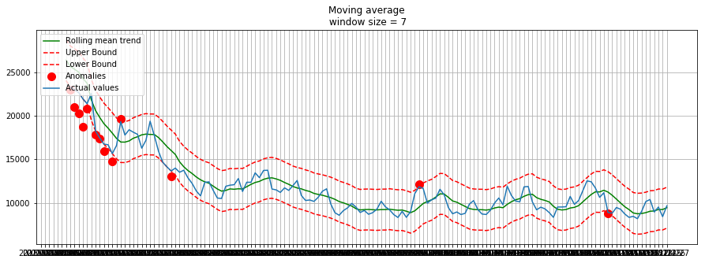

```python
dfsn_io = RemoveOutliers(dfs.iloc[:150,98], 7, plot_intervals=True, plot_anomalies=True)

dfsn_io.to_csv('C:\ML Projects\WebTrafficPrediction\FinalCodeforWebsite\data\io\dfsn_io.csv')
```

Next the series is decomposed to show the trend, seasonality and residue in the data:

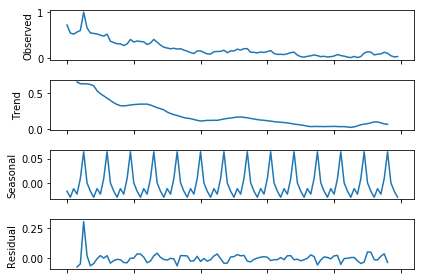

```python
plt.figure(figsize=(500, 500))
sm.tsa.seasonal_decompose(dfsn_io[:100], freq=7).plot()
plt.show()
```

We run the Dickey-Fuller Test to determine if is stationary.

```python
AdFullerTest(dfsn_io[:56])
```

```
Results of Dickey-Fuller Test
Test Statistic                 -2.461673
p-value                         0.125080
#Lags Used                      8.000000
Number of Observations Used    47.000000
Critical Value (1%)            -3.577848
Critical Value (5%)            -2.925338
Critical Value (10%)           -2.600774
dtype: float64
```

Since t-stats > critical value, series is not stationary. This is also evident from the ACF plot which is decaying slowly.

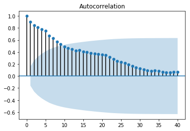

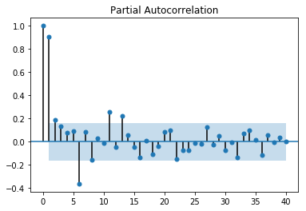

```python
PlotCorrelationFunc(dfsn_io, 40)
```

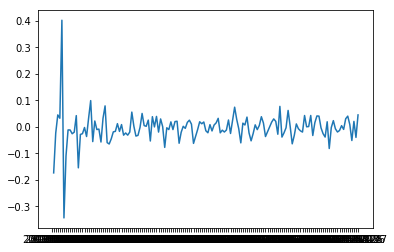

```python
dfsn_io_diff = dfsn_io - dfsn_io.shift()
plt.plot(dfsn_io_diff)
dfsn_io_diff.dropna(inplace=True)
```

This series looks like white noise. Next we look at the ACF and PACF plots

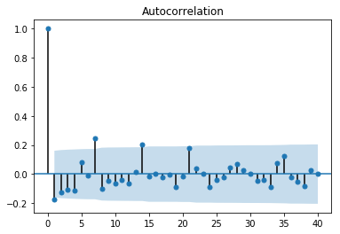

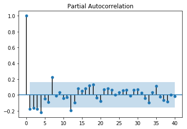

```python
PlotCorrelationFunc(dfsn_io_diff, 40)
```

The ACF shows that there is a strong correlation with every 7th value. So the order of seasonality is 7. Dickey Fuller test is carried out on the differenced series.

```python
AdFullerTest(dfsn_io_diff[:56])
```

```
Results of Dickey-Fuller Test
Test Statistic                 -4.107944
p-value                         0.000940
#Lags Used                     11.000000
Number of Observations Used    44.000000
Critical Value (1%)            -3.588573
Critical Value (5%)            -2.929886
Critical Value (10%)           -2.603185
dtype: float64
```

t-stats < critical value implying that series is stationary. This is also evident from the ACF plot decays rapidly. Based on this, A good model for SARIMA may be:

(p,d,q)(P,D,Q)_m : (2,1,0)(1,1,1)_7

The following code runs SARIMA for difference value of p,d,q to determine the optimum values:

```
Fit ARIMA: order=(0, 1, 0) seasonal_order=(0, 1, 1, 7); AIC=-256.553, BIC=-248.988, Fit time=0.731 seconds
Fit ARIMA: order=(0, 1, 0) seasonal_order=(0, 1, 0, 7); AIC=-253.971, BIC=-248.928, Fit time=0.361 seconds
Fit ARIMA: order=(1, 1, 0) seasonal_order=(1, 1, 0, 7); AIC=-256.256, BIC=-246.168, Fit time=0.812 seconds
Fit ARIMA: order=(0, 1, 1) seasonal_order=(0, 1, 1, 7); AIC=-256.164, BIC=-246.077, Fit time=1.520 seconds
Fit ARIMA: order=(0, 1, 0) seasonal_order=(1, 1, 1, 7); AIC=-255.262, BIC=-245.175, Fit time=1.646 seconds
Fit ARIMA: order=(0, 1, 0) seasonal_order=(0, 1, 2, 7); AIC=-239.651, BIC=-229.564, Fit time=1.778 seconds
Fit ARIMA: order=(0, 1, 0) seasonal_order=(1, 1, 2, 7); AIC=-254.083, BIC=-241.474, Fit time=5.265 seconds
Fit ARIMA: order=(1, 1, 0) seasonal_order=(0, 1, 1, 7); AIC=-255.554, BIC=-245.467, Fit time=0.552 seconds
Fit ARIMA: order=(1, 1, 1) seasonal_order=(0, 1, 1, 7); AIC=nan, BIC=nan, Fit time=nan seconds
Total fit time: 12.674 seconds

Least AIC: -256.55287049608586
Least BIC: -248.98750476493873
order: (0, 1, 0)
seasonal order: (0, 1, 1, 7)
```

```
                                               Statespace Model Results
======================================================================================================================
Dep. Variable:     Inside_Out_(2015_film)_en.wikipedia.org_desktop_all-agents   No. Observations:                  100
Model:                                          SARIMAX(0, 1, 0)x(0, 1, 1, 7)   Log Likelihood                 158.516
Date:                                                        Wed, 26 Jun 2019   AIC                           -313.032
Time:                                                                17:17:34   BIC                           -308.170
Sample:                                                            07-01-2015   HQIC                          -311.078
                                                                 - 10-08-2015
Covariance Type:                                                          opg
==============================================================================
                 coef    std err          z      P>|z|      [0.025      0.975]
------------------------------------------------------------------------------
ma.S.L7       -0.1544      0.056     -2.739      0.006      -0.265      -0.044
sigma2         0.0013      0.000      8.006      0.000       0.001       0.002
===================================================================================
Ljung-Box (Q):                       52.21   Jarque-Bera (JB):                11.40
Prob(Q):                              0.09   Prob(JB):                         0.00
Heteroskedasticity (H):               0.73   Skew:                             0.34
Prob(H) (two-sided):                  0.41   Kurtosis:                         4.67
===================================================================================

Warnings:
[1] Covariance matrix calculated using the outer product of gradients (complex-step).

Plotting Diagnostics
```

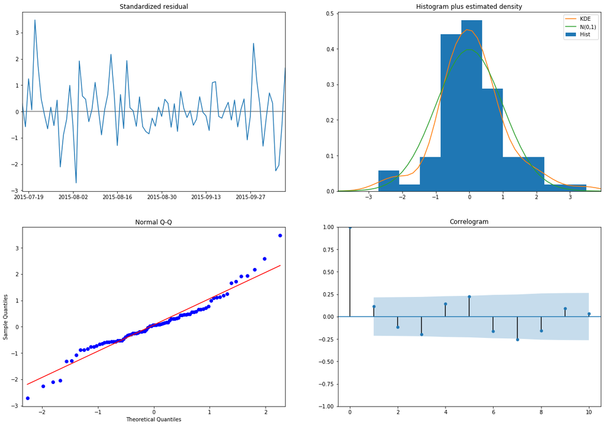

```python
#https://www.alkaline-ml.com/pmdarima/quickstart.html#auto-arima-example
#https://github.com/Vijayganeshsrinivasan/Forecasting-using-ARIMA-method/blob/master/FINAL_FORECASTING.ipynb

stepwise_model = auto_arima(dfsn_io[:100], start_p=0, start_q=0,
                            max_p=4, max_q=3, m=7, start_P=0,
                            seasonal=True,d=1, D=1, trace=True, error_action='ignore',
                            suppress_warnings=True,stepwise=True,)
order_in = stepwise_model.order
seasonal_order_in = stepwise_model.seasonal_order
print('\nLeast AIC: '+ str(stepwise_model.aic()))
print('Least BIC: '+ str(stepwise_model.bic()))
print('order: '+ str(order_in))
print('seasonal order: '+ str(seasonal_order_in))

# order=order_in,  seasonal_order=seasonal_order_in,

mod = sm.tsa.statespace.SARIMAX(dfsn_io[:100], trend='n', order=(0,1,0),  seasonal_order=(0,1,1,7), enforce_invertibility=False, enforce_stationarity = False)
results = mod.fit()
print(results.summary())

print('\nPlotting Diagnostics')
results.plot_diagnostics(figsize=(20, 14))
plt.show()

predict = results.forecast(70)
predict.to_csv('C:\ML Projects\WebTrafficPrediction\FinalCodeforWebsite\data\io\predict70.csv')
#plt.plot(predict)
#plt.plot(dfsn_io)
```

The code proposes the following model parameters:

(p,d,q)(P,D,Q)_m : (0,1,0)(0,1,1)_7

We run the ARIMAStepWisePrediction to make prediction with different step sizes of 7,14 and 21.

```python
predict7 = ARIMAStepWisePrediction(dfsn_io,7)
predict7.to_csv('C:\ML Projects\WebTrafficPrediction\FinalCodeforWebsite\data\io\predict7.csv')
```

[output not shown]

```
Fit ARIMA: order=(0, 1, 0) seasonal_order=(0, 1, 1, 7); AIC=nan, BIC=nan, Fit time=nan seconds
Fit ARIMA: order=(0, 1, 0) seasonal_order=(0, 1, 0, 7); AIC=-28.970, BIC=-26.979, Fit time=0.059 seconds
Fit ARIMA: order=(1, 1, 0) seasonal_order=(1, 1, 0, 7); AIC=-25.169, BIC=-21.186, Fit time=0.616 seconds
Fit ARIMA: order=(0, 1, 1) seasonal_order=(0, 1, 1, 7); AIC=nan, BIC=nan, Fit time=nan seconds
Fit ARIMA: order=(0, 1, 0) seasonal_order=(1, 1, 0, 7); AIC=-27.003, BIC=-24.016, Fit time=0.551 seconds
Fit ARIMA: order=(0, 1, 0) seasonal_order=(1, 1, 1, 7); AIC=nan, BIC=nan, Fit time=nan seconds
Fit ARIMA: order=(1, 1, 0) seasonal_order=(0, 1, 0, 7); AIC=-27.086, BIC=-24.099, Fit time=0.267 seconds
Fit ARIMA: order=(0, 1, 1) seasonal_order=(0, 1, 0, 7); AIC=-27.117, BIC=-24.130, Fit time=0.324 seconds
Fit ARIMA: order=(1, 1, 1) seasonal_order=(0, 1, 0, 7); AIC=-27.445, BIC=-23.462, Fit time=1.089 seconds
Total fit time: 2.928 seconds

Least AIC: -28.97036650775035
Least BIC: -26.978901960642368
order: (0, 1, 0)
seasonal order: (0, 1, 0, 7)
i= 1
2 35
Fit ARIMA: order=(0, 1, 0) seasonal_order=(0, 1, 1, 7); AIC=nan, BIC=nan, Fit time=nan seconds
```

```
Fit ARIMA: order=(0, 1, 0) seasonal_order=(0, 1, 0, 7); AIC=-45.634, BIC=-43.042, Fit time=0.090 seconds
Fit ARIMA: order=(1, 1, 0) seasonal_order=(1, 1, 0, 7); AIC=-41.983, BIC=-36.799, Fit time=0.674 seconds
Fit ARIMA: order=(0, 1, 1) seasonal_order=(0, 1, 1, 7); AIC=nan, BIC=nan, Fit time=nan seconds
Fit ARIMA: order=(0, 1, 0) seasonal_order=(1, 1, 0, 7); AIC=-43.713, BIC=-39.825, Fit time=0.306 seconds
Fit ARIMA: order=(0, 1, 0) seasonal_order=(1, 1, 1, 7); AIC=nan, BIC=nan, Fit time=nan seconds
Fit ARIMA: order=(1, 1, 0) seasonal_order=(0, 1, 0, 7); AIC=-43.792, BIC=-39.904, Fit time=0.975 seconds
Fit ARIMA: order=(0, 1, 1) seasonal_order=(0, 1, 0, 7); AIC=-43.836, BIC=-39.948, Fit time=0.261 seconds
Fit ARIMA: order=(1, 1, 1) seasonal_order=(0, 1, 0, 7); AIC=-44.526, BIC=-39.343, Fit time=0.886 seconds
Total fit time: 3.219 seconds

Least AIC: -45.63408355690188
Least BIC: -43.04240982489322
order: (0, 1, 0)
seasonal order: (0, 1, 0, 7)
i= 2
3 42
```

```
Fit ARIMA: order=(0, 1, 0) seasonal_order=(0, 1, 1, 7); AIC=-63.903, BIC=-59.324, Fit time=0.494 seconds
Fit ARIMA: order=(0, 1, 0) seasonal_order=(0, 1, 0, 7); AIC=-65.573, BIC=-62.520, Fit time=0.238 seconds
Fit ARIMA: order=(1, 1, 0) seasonal_order=(1, 1, 0, 7); AIC=-62.392, BIC=-56.286, Fit time=1.604 seconds
Fit ARIMA: order=(0, 1, 1) seasonal_order=(0, 1, 1, 7); AIC=-62.449, BIC=-56.344, Fit time=1.685 seconds
Fit ARIMA: order=(0, 1, 0) seasonal_order=(1, 1, 0, 7); AIC=-63.980, BIC=-59.401, Fit time=0.235 seconds
Fit ARIMA: order=(0, 1, 0) seasonal_order=(1, 1, 1, 7); AIC=-62.139, BIC=-56.034, Fit time=0.402 seconds
Fit ARIMA: order=(1, 1, 0) seasonal_order=(0, 1, 0, 7); AIC=-63.712, BIC=-59.132, Fit time=0.131 seconds
Fit ARIMA: order=(0, 1, 1) seasonal_order=(0, 1, 0, 7); AIC=-63.758, BIC=-59.179, Fit time=0.472 seconds
Fit ARIMA: order=(1, 1, 1) seasonal_order=(0, 1, 0, 7); AIC=-63.443, BIC=-57.338, Fit time=0.490 seconds
Total fit time: 5.755 seconds

Least AIC: -65.57272293199652
Least BIC: -62.5200018827642
order: (0, 1, 0)
seasonal order: (0, 1, 0, 7)
i= 3
4 49
```

```
Fit ARIMA: order=(0, 1, 0) seasonal_order=(0, 1, 1, 7); AIC=-84.360, BIC=-79.219, Fit time=0.354 seconds
Fit ARIMA: order=(0, 1, 0) seasonal_order=(0, 1, 0, 7); AIC=-85.843, BIC=-82.416, Fit time=0.071 seconds
Fit ARIMA: order=(1, 1, 0) seasonal_order=(1, 1, 0, 7); AIC=-82.943, BIC=-76.088, Fit time=0.590 seconds
Fit ARIMA: order=(0, 1, 1) seasonal_order=(0, 1, 1, 7); AIC=-83.025, BIC=-76.171, Fit time=1.538 seconds
Fit ARIMA: order=(0, 1, 0) seasonal_order=(1, 1, 0, 7); AIC=-84.455, BIC=-79.314, Fit time=0.569 seconds
Fit ARIMA: order=(0, 1, 0) seasonal_order=(1, 1, 1, 7); AIC=-82.530, BIC=-75.675, Fit time=1.599 seconds
Fit ARIMA: order=(1, 1, 0) seasonal_order=(0, 1, 0, 7); AIC=-83.984, BIC=-78.843, Fit time=0.552 seconds
Fit ARIMA: order=(0, 1, 1) seasonal_order=(0, 1, 0, 7); AIC=-84.035, BIC=-78.894, Fit time=0.208 seconds
Fit ARIMA: order=(1, 1, 1) seasonal_order=(0, 1, 0, 7); AIC=nan, BIC=nan, Fit time=nan seconds
Total fit time: 5.492 seconds

Least AIC: -85.84266953454774
Least BIC: -82.41552540113912
order: (0, 1, 0)
seasonal order: (0, 1, 0, 7)
i= 4
5 56
```

```
Fit ARIMA: order=(0, 1, 0) seasonal_order=(0, 1, 1, 7); AIC=-106.135, BIC=-100.521, Fit time=0.531 seconds
Fit ARIMA: order=(0, 1, 0) seasonal_order=(0, 1, 0, 7); AIC=-107.396, BIC=-103.654, Fit time=0.094 seconds
Fit ARIMA: order=(1, 1, 0) seasonal_order=(1, 1, 0, 7); AIC=-104.980, BIC=-97.496, Fit time=0.657 seconds
Fit ARIMA: order=(0, 1, 1) seasonal_order=(0, 1, 1, 7); AIC=-105.001, BIC=-97.516, Fit time=1.462 seconds
Fit ARIMA: order=(0, 1, 0) seasonal_order=(1, 1, 0, 7); AIC=-106.309, BIC=-100.695, Fit time=0.651 seconds
Fit ARIMA: order=(0, 1, 0) seasonal_order=(1, 1, 1, 7); AIC=-104.315, BIC=-96.830, Fit time=1.095 seconds
Fit ARIMA: order=(1, 1, 0) seasonal_order=(0, 1, 0, 7); AIC=-105.592, BIC=-99.978, Fit time=0.468 seconds
Fit ARIMA: order=(0, 1, 1) seasonal_order=(0, 1, 0, 7); AIC=-105.662, BIC=-100.049, Fit time=0.409 seconds
Fit ARIMA: order=(1, 1, 1) seasonal_order=(0, 1, 0, 7); AIC=nan, BIC=nan, Fit time=nan seconds
Total fit time: 5.378 seconds

Least AIC: -107.39616976570014
Least BIC: -103.65376774388436
order: (0, 1, 0)
seasonal order: (0, 1, 0, 7)
i= 5
6 63
```

```
Fit ARIMA: order=(0, 1, 0) seasonal_order=(0, 1, 1, 7); AIC=-129.594, BIC=-123.572, Fit time=0.520 seconds
Fit ARIMA: order=(0, 1, 0) seasonal_order=(0, 1, 0, 7); AIC=-130.447, BIC=-126.433, Fit time=0.083 seconds
Fit ARIMA: order=(1, 1, 0) seasonal_order=(1, 1, 0, 7); AIC=-128.564, BIC=-120.534, Fit time=0.987 seconds
Fit ARIMA: order=(0, 1, 1) seasonal_order=(0, 1, 1, 7); AIC=-128.570, BIC=-120.541, Fit time=1.651 seconds
Fit ARIMA: order=(0, 1, 0) seasonal_order=(1, 1, 0, 7); AIC=-129.816, BIC=-123.794, Fit time=0.390 seconds
Fit ARIMA: order=(0, 1, 0) seasonal_order=(1, 1, 1, 7); AIC=-127.816, BIC=-119.787, Fit time=1.096 seconds
Fit ARIMA: order=(1, 1, 0) seasonal_order=(0, 1, 0, 7); AIC=-128.624, BIC=-122.602, Fit time=1.203 seconds
Fit ARIMA: order=(0, 1, 1) seasonal_order=(0, 1, 0, 7); AIC=-128.678, BIC=-122.656, Fit time=1.503 seconds
Fit ARIMA: order=(1, 1, 1) seasonal_order=(0, 1, 0, 7); AIC=nan, BIC=nan, Fit time=nan seconds
Total fit time: 7.442 seconds

Least AIC: -130.4474023222442
Least BIC: -126.43273595177925
order: (0, 1, 0)
seasonal order: (0, 1, 0, 7)
i= 6
7 70
```

```
Fit ARIMA: order=(0, 1, 0) seasonal_order=(0, 1, 1, 7); AIC=-153.751, BIC=-147.370, Fit time=0.614 seconds
Fit ARIMA: order=(0, 1, 0) seasonal_order=(0, 1, 0, 7); AIC=-154.541, BIC=-150.287, Fit time=0.096 seconds
Fit ARIMA: order=(1, 1, 0) seasonal_order=(1, 1, 0, 7); AIC=-152.811, BIC=-144.302, Fit time=0.857 seconds
Fit ARIMA: order=(0, 1, 1) seasonal_order=(0, 1, 1, 7); AIC=-152.958, BIC=-144.450, Fit time=2.164 seconds
Fit ARIMA: order=(0, 1, 0) seasonal_order=(1, 1, 0, 7); AIC=-153.926, BIC=-147.545, Fit time=1.328 seconds
Fit ARIMA: order=(0, 1, 0) seasonal_order=(1, 1, 1, 7); AIC=-151.927, BIC=-143.419, Fit time=1.129 seconds
Fit ARIMA: order=(1, 1, 0) seasonal_order=(0, 1, 0, 7); AIC=-152.774, BIC=-146.393, Fit time=0.472 seconds
Fit ARIMA: order=(0, 1, 1) seasonal_order=(0, 1, 0, 7); AIC=-152.847, BIC=-146.465, Fit time=0.486 seconds
Fit ARIMA: order=(1, 1, 1) seasonal_order=(0, 1, 0, 7); AIC=nan, BIC=nan, Fit time=nan seconds
Total fit time: 7.159 seconds

Least AIC: -154.54077261242875
Least BIC: -150.28650384233856
order: (0, 1, 0)
seasonal order: (0, 1, 0, 7)
```

```
i= 7
8 77
Fit ARIMA: order=(0, 1, 0) seasonal_order=(0, 1, 1, 7); AIC=-178.371, BIC=-171.669, Fit time=1.603 seconds
Fit ARIMA: order=(0, 1, 0) seasonal_order=(0, 1, 0, 7); AIC=-179.001, BIC=-174.533, Fit time=0.098 seconds
Fit ARIMA: order=(1, 1, 0) seasonal_order=(1, 1, 0, 7); AIC=-177.620, BIC=-168.683, Fit time=1.432 seconds
Fit ARIMA: order=(0, 1, 1) seasonal_order=(0, 1, 1, 7); AIC=-177.794, BIC=-168.857, Fit time=1.873 seconds
Fit ARIMA: order=(0, 1, 0) seasonal_order=(1, 1, 0, 7); AIC=-178.578, BIC=-171.876, Fit time=0.825 seconds
Fit ARIMA: order=(0, 1, 0) seasonal_order=(1, 1, 1, 7); AIC=-176.578, BIC=-167.642, Fit time=1.827 seconds
Fit ARIMA: order=(1, 1, 0) seasonal_order=(0, 1, 0, 7); AIC=-177.287, BIC=-170.585, Fit time=0.692 seconds
Fit ARIMA: order=(0, 1, 1) seasonal_order=(0, 1, 0, 7); AIC=-177.378, BIC=-170.675, Fit time=0.772 seconds
Fit ARIMA: order=(1, 1, 1) seasonal_order=(0, 1, 0, 7); AIC=nan, BIC=nan, Fit time=nan seconds
Total fit time: 9.137 seconds

Least AIC: -179.00105597984953
Least BIC: -174.532842970655
order: (0, 1, 0)
seasonal order: (0, 1, 0, 7)
i= 8
9 84
```

```
Fit ARIMA: order=(0, 1, 0) seasonal_order=(0, 1, 1, 7); AIC=-203.845, BIC=-196.853, Fit time=1.799 seconds
Fit ARIMA: order=(0, 1, 0) seasonal_order=(0, 1, 0, 7); AIC=-204.282, BIC=-199.621, Fit time=0.307 seconds
Fit ARIMA: order=(1, 1, 0) seasonal_order=(1, 1, 0, 7); AIC=-203.163, BIC=-193.840, Fit time=1.187 seconds
Fit ARIMA: order=(0, 1, 1) seasonal_order=(0, 1, 1, 7); AIC=-203.376, BIC=-194.053, Fit time=1.905 seconds
Fit ARIMA: order=(0, 1, 0) seasonal_order=(1, 1, 0, 7); AIC=-204.068, BIC=-197.076, Fit time=0.463 seconds
Fit ARIMA: order=(0, 1, 0) seasonal_order=(1, 1, 1, 7); AIC=-202.065, BIC=-192.742, Fit time=1.709 seconds
Fit ARIMA: order=(1, 1, 0) seasonal_order=(0, 1, 0, 7); AIC=-202.547, BIC=-195.555, Fit time=1.186 seconds
Fit ARIMA: order=(0, 1, 1) seasonal_order=(0, 1, 0, 7); AIC=-202.635, BIC=-195.643, Fit time=0.908 seconds
Fit ARIMA: order=(1, 1, 1) seasonal_order=(0, 1, 0, 7); AIC=nan, BIC=nan, Fit time=nan seconds
Total fit time: 9.491 seconds

Least AIC: -204.28244240420145
Least BIC: -199.6209757236288
order: (0, 1, 0)
seasonal order: (0, 1, 0, 7)
```

```
i= 9
10 91
Fit ARIMA: order=(0, 1, 0) seasonal_order=(0, 1, 1, 7); AIC=-226.895, BIC=-219.639, Fit time=1.390 seconds
Fit ARIMA: order=(0, 1, 0) seasonal_order=(0, 1, 0, 7); AIC=-226.970, BIC=-222.132, Fit time=0.374 seconds
Fit ARIMA: order=(1, 1, 0) seasonal_order=(1, 1, 0, 7); AIC=-226.153, BIC=-216.478, Fit time=1.240 seconds
Fit ARIMA: order=(0, 1, 1) seasonal_order=(0, 1, 1, 7); AIC=-226.274, BIC=-216.599, Fit time=2.519 seconds
Fit ARIMA: order=(0, 1, 0) seasonal_order=(1, 1, 0, 7); AIC=-227.177, BIC=-219.920, Fit time=0.647 seconds
Fit ARIMA: order=(0, 1, 0) seasonal_order=(1, 1, 1, 7); AIC=-225.097, BIC=-215.421, Fit time=2.396 seconds
Fit ARIMA: order=(0, 1, 0) seasonal_order=(2, 1, 1, 7); AIC=-223.855, BIC=-211.761, Fit time=2.303 seconds
Fit ARIMA: order=(0, 1, 1) seasonal_order=(1, 1, 0, 7); AIC=-226.634, BIC=-216.959, Fit time=1.194 seconds
Fit ARIMA: order=(1, 1, 1) seasonal_order=(1, 1, 0, 7); AIC=nan, BIC=nan, Fit time=nan seconds
Fit ARIMA: order=(0, 1, 0) seasonal_order=(2, 1, 0, 7); AIC=-225.184, BIC=-215.509, Fit time=2.262 seconds
Total fit time: 14.335 seconds

Least AIC: -227.17698936979951
Least BIC: -219.92046754640972
order: (0, 1, 0)
seasonal order: (1, 1, 0, 7)
i= 10
11 98
```

```
Fit ARIMA: order=(0, 1, 0) seasonal_order=(0, 1, 1, 7); AIC=-249.687, BIC=-242.187, Fit time=0.980 seconds
Fit ARIMA: order=(0, 1, 0) seasonal_order=(0, 1, 0, 7); AIC=-247.734, BIC=-242.735, Fit time=0.470 seconds
Fit ARIMA: order=(1, 1, 0) seasonal_order=(1, 1, 0, 7); AIC=-249.233, BIC=-239.234, Fit time=2.544 seconds
Fit ARIMA: order=(0, 1, 1) seasonal_order=(0, 1, 1, 7); AIC=-249.194, BIC=-239.195, Fit time=3.039 seconds
Fit ARIMA: order=(0, 1, 0) seasonal_order=(1, 1, 1, 7); AIC=-246.852, BIC=-236.853, Fit time=0.276 seconds
Fit ARIMA: order=(0, 1, 0) seasonal_order=(0, 1, 2, 7); AIC=-232.855, BIC=-222.856, Fit time=2.532 seconds
Fit ARIMA: order=(0, 1, 0) seasonal_order=(1, 1, 2, 7); AIC=-247.173, BIC=-234.674, Fit time=4.672 seconds
Fit ARIMA: order=(1, 1, 0) seasonal_order=(0, 1, 1, 7); AIC=-248.635, BIC=-238.636, Fit time=0.652 seconds
Fit ARIMA: order=(1, 1, 1) seasonal_order=(0, 1, 1, 7); AIC=nan, BIC=nan, Fit time=nan seconds
Total fit time: 15.173 seconds

Least AIC: -249.68669498638087
Least BIC: -242.18726597539006
order: (0, 1, 0)
seasonal order: (0, 1, 1, 7)
i= 11
12 105
```

```
Fit ARIMA: order=(0, 1, 0) seasonal_order=(0, 1, 1, 7); AIC=-275.660, BIC=-267.936, Fit time=0.501 seconds
Fit ARIMA: order=(0, 1, 0) seasonal_order=(0, 1, 0, 7); AIC=-272.476, BIC=-267.327, Fit time=0.099 seconds
Fit ARIMA: order=(1, 1, 0) seasonal_order=(1, 1, 0, 7); AIC=-275.422, BIC=-265.123, Fit time=0.661 seconds
Fit ARIMA: order=(0, 1, 1) seasonal_order=(0, 1, 1, 7); AIC=-275.516, BIC=-265.218, Fit time=3.787 seconds
Fit ARIMA: order=(0, 1, 0) seasonal_order=(1, 1, 1, 7); AIC=-274.341, BIC=-264.042, Fit time=2.789 seconds
Fit ARIMA: order=(0, 1, 0) seasonal_order=(0, 1, 2, 7); AIC=-258.321, BIC=-248.022, Fit time=3.177 seconds
Fit ARIMA: order=(0, 1, 0) seasonal_order=(1, 1, 2, 7); AIC=-272.958, BIC=-260.085, Fit time=4.158 seconds
Fit ARIMA: order=(1, 1, 0) seasonal_order=(0, 1, 1, 7); AIC=-274.834, BIC=-264.535, Fit time=0.812 seconds
Fit ARIMA: order=(1, 1, 1) seasonal_order=(0, 1, 1, 7); AIC=nan, BIC=nan, Fit time=nan seconds
Total fit time: 15.991 seconds

Least AIC: -275.66033248521853
Least BIC: -267.93619954970836
order: (0, 1, 0)
seasonal order: (0, 1, 1, 7)
```

```
i= 12
13 112
Fit ARIMA: order=(0, 1, 0) seasonal_order=(0, 1, 1, 7); AIC=-298.459, BIC=-290.526, Fit time=1.747 seconds
Fit ARIMA: order=(0, 1, 0) seasonal_order=(0, 1, 0, 7); AIC=-294.658, BIC=-289.370, Fit time=0.227 seconds
Fit ARIMA: order=(1, 1, 0) seasonal_order=(1, 1, 0, 7); AIC=-298.026, BIC=-287.448, Fit time=1.591 seconds
Fit ARIMA: order=(0, 1, 1) seasonal_order=(0, 1, 1, 7); AIC=-299.083, BIC=-288.505, Fit time=3.431 seconds
Fit ARIMA: order=(0, 1, 1) seasonal_order=(1, 1, 1, 7); AIC=-297.771, BIC=-284.549, Fit time=2.014 seconds
Fit ARIMA: order=(0, 1, 1) seasonal_order=(0, 1, 0, 7); AIC=-292.844, BIC=-284.911, Fit time=0.242 seconds
Fit ARIMA: order=(0, 1, 1) seasonal_order=(0, 1, 2, 7); AIC=-298.115, BIC=-284.893, Fit time=5.538 seconds
Fit ARIMA: order=(0, 1, 1) seasonal_order=(1, 1, 2, 7); AIC=-295.946, BIC=-280.079, Fit time=4.659 seconds
Fit ARIMA: order=(1, 1, 1) seasonal_order=(0, 1, 1, 7); AIC=nan, BIC=nan, Fit time=nan seconds
Fit ARIMA: order=(0, 1, 2) seasonal_order=(0, 1, 1, 7); AIC=-300.968, BIC=-287.746, Fit time=2.863 seconds
Fit ARIMA: order=(1, 1, 3) seasonal_order=(0, 1, 1, 7); AIC=-299.357, BIC=-280.846, Fit time=3.281 seconds
Fit ARIMA: order=(0, 1, 2) seasonal_order=(1, 1, 1, 7); AIC=-299.032, BIC=-283.166, Fit time=2.806 seconds
Fit ARIMA: order=(0, 1, 2) seasonal_order=(0, 1, 0, 7); AIC=-294.336, BIC=-283.759, Fit time=0.975 seconds
Fit ARIMA: order=(0, 1, 2) seasonal_order=(0, 1, 2, 7); AIC=-299.790, BIC=-283.923, Fit time=5.144 seconds
Fit ARIMA: order=(0, 1, 2) seasonal_order=(1, 1, 2, 7); AIC=-297.679, BIC=-279.168, Fit time=5.471 seconds
Fit ARIMA: order=(1, 1, 2) seasonal_order=(0, 1, 1, 7); AIC=-299.801, BIC=-283.934, Fit time=3.752 seconds
Fit ARIMA: order=(0, 1, 3) seasonal_order=(0, 1, 1, 7); AIC=-300.834, BIC=-284.968, Fit time=3.273 seconds
Total fit time: 47.024 seconds

Least AIC: -300.9682127196147
Least BIC: -287.74625822390783
order: (0, 1, 2)
seasonal order: (0, 1, 1, 7)
```

```
i= 13
14 119
Fit ARIMA: order=(0, 1, 0) seasonal_order=(0, 1, 1, 7); AIC=-322.420, BIC=-314.292, Fit time=1.034 seconds
Fit ARIMA: order=(0, 1, 0) seasonal_order=(0, 1, 0, 7); AIC=-316.757, BIC=-311.338, Fit time=0.130 seconds
Fit ARIMA: order=(1, 1, 0) seasonal_order=(1, 1, 0, 7); AIC=-321.827, BIC=-310.989, Fit time=1.539 seconds
Fit ARIMA: order=(0, 1, 1) seasonal_order=(0, 1, 1, 7); AIC=-322.948, BIC=-312.110, Fit time=6.778 seconds
Fit ARIMA: order=(0, 1, 1) seasonal_order=(1, 1, 1, 7); AIC=-321.862, BIC=-308.314, Fit time=2.659 seconds
Fit ARIMA: order=(0, 1, 1) seasonal_order=(0, 1, 0, 7); AIC=-314.877, BIC=-306.749, Fit time=0.343 seconds
Fit ARIMA: order=(0, 1, 1) seasonal_order=(0, 1, 2, 7); AIC=-322.547, BIC=-309.000, Fit time=3.101 seconds
Fit ARIMA: order=(0, 1, 1) seasonal_order=(1, 1, 2, 7); AIC=-320.331, BIC=-304.073, Fit time=4.462 seconds
Fit ARIMA: order=(1, 1, 1) seasonal_order=(0, 1, 1, 7); AIC=nan, BIC=nan, Fit time=nan seconds
Fit ARIMA: order=(0, 1, 2) seasonal_order=(0, 1, 1, 7); AIC=-325.136, BIC=-311.588, Fit time=2.824 seconds
Fit ARIMA: order=(1, 1, 3) seasonal_order=(0, 1, 1, 7); AIC=-323.343, BIC=-304.376, Fit time=2.141 seconds
Fit ARIMA: order=(0, 1, 2) seasonal_order=(1, 1, 1, 7); AIC=-324.090, BIC=-307.833, Fit time=3.003 seconds
Fit ARIMA: order=(0, 1, 2) seasonal_order=(0, 1, 0, 7); AIC=-316.161, BIC=-305.323, Fit time=2.128 seconds
Fit ARIMA: order=(0, 1, 2) seasonal_order=(0, 1, 2, 7); AIC=-324.709, BIC=-308.452, Fit time=4.167 seconds
Fit ARIMA: order=(0, 1, 2) seasonal_order=(1, 1, 2, 7); AIC=-322.538, BIC=-303.571, Fit time=5.219 seconds
Fit ARIMA: order=(1, 1, 2) seasonal_order=(0, 1, 1, 7); AIC=-322.799, BIC=-306.542, Fit time=7.186 seconds
Fit ARIMA: order=(0, 1, 3) seasonal_order=(0, 1, 1, 7); AIC=-325.476, BIC=-309.219, Fit time=3.700 seconds
Fit ARIMA: order=(0, 1, 3) seasonal_order=(1, 1, 1, 7); AIC=-323.286, BIC=-304.319, Fit time=3.839 seconds
Fit ARIMA: order=(0, 1, 3) seasonal_order=(0, 1, 0, 7); AIC=-316.222, BIC=-302.675, Fit time=1.588 seconds
Fit ARIMA: order=(0, 1, 3) seasonal_order=(0, 1, 2, 7); AIC=-324.522, BIC=-305.556, Fit time=5.847 seconds
Fit ARIMA: order=(0, 1, 3) seasonal_order=(1, 1, 2, 7); AIC=-322.299, BIC=-300.623, Fit time=5.692 seconds
Total fit time: 67.392 seconds

Least AIC: -325.47597481352153
Least BIC: -309.21879360564753
order: (0, 1, 3)
seasonal order: (0, 1, 1, 7)
```

```
i= 14
15 126
Fit ARIMA: order=(0, 1, 0) seasonal_order=(0, 1, 1, 7); AIC=-347.276, BIC=-338.964, Fit time=0.456 seconds
Fit ARIMA: order=(0, 1, 0) seasonal_order=(0, 1, 0, 7); AIC=-339.014, BIC=-333.473, Fit time=0.071 seconds
Fit ARIMA: order=(1, 1, 0) seasonal_order=(1, 1, 0, 7); AIC=-346.390, BIC=-335.308, Fit time=1.458 seconds
Fit ARIMA: order=(0, 1, 1) seasonal_order=(0, 1, 1, 7); AIC=-348.699, BIC=-337.616, Fit time=3.143 seconds
Fit ARIMA: order=(0, 1, 1) seasonal_order=(1, 1, 1, 7); AIC=-347.723, BIC=-333.869, Fit time=3.114 seconds
Fit ARIMA: order=(0, 1, 1) seasonal_order=(0, 1, 0, 7); AIC=-337.202, BIC=-328.890, Fit time=0.535 seconds
Fit ARIMA: order=(0, 1, 1) seasonal_order=(0, 1, 2, 7); AIC=-348.292, BIC=-334.439, Fit time=3.330 seconds
Fit ARIMA: order=(0, 1, 1) seasonal_order=(1, 1, 2, 7); AIC=-346.044, BIC=-329.419, Fit time=3.930 seconds
Fit ARIMA: order=(1, 1, 1) seasonal_order=(0, 1, 1, 7); AIC=nan, BIC=nan, Fit time=nan seconds
Fit ARIMA: order=(0, 1, 2) seasonal_order=(0, 1, 1, 7); AIC=-351.468, BIC=-337.615, Fit time=3.735 seconds
Fit ARIMA: order=(1, 1, 3) seasonal_order=(0, 1, 1, 7); AIC=-349.394, BIC=-329.999, Fit time=4.577 seconds
Fit ARIMA: order=(0, 1, 2) seasonal_order=(1, 1, 1, 7); AIC=-350.436, BIC=-333.812, Fit time=3.161 seconds
Fit ARIMA: order=(0, 1, 2) seasonal_order=(0, 1, 0, 7); AIC=-339.372, BIC=-328.290, Fit time=0.519 seconds
Fit ARIMA: order=(0, 1, 2) seasonal_order=(0, 1, 2, 7); AIC=-350.759, BIC=-334.135, Fit time=4.060 seconds
Fit ARIMA: order=(0, 1, 2) seasonal_order=(1, 1, 2, 7); AIC=-348.716, BIC=-329.321, Fit time=4.385 seconds
Fit ARIMA: order=(1, 1, 2) seasonal_order=(0, 1, 1, 7); AIC=-348.672, BIC=-332.048, Fit time=4.737 seconds
```

```
Fit ARIMA: order=(0, 1, 3) seasonal_order=(0, 1, 1, 7); AIC=-351.337, BIC=-334.713, Fit time=4.293 seconds
Total fit time: 45.515 seconds

Least AIC: -351.4684579807846
Least BIC: -337.6150348584563
order: (0, 1, 2)
seasonal order: (0, 1, 1, 7)
```

```
i= 15
16 133
Fit ARIMA: order=(0, 1, 0) seasonal_order=(0, 1, 1, 7); AIC=-373.667, BIC=-365.182, Fit time=0.586 seconds
Fit ARIMA: order=(0, 1, 0) seasonal_order=(0, 1, 0, 7); AIC=-364.311, BIC=-358.654, Fit time=0.057 seconds
Fit ARIMA: order=(1, 1, 0) seasonal_order=(1, 1, 0, 7); AIC=-373.006, BIC=-361.693, Fit time=1.445 seconds
Fit ARIMA: order=(0, 1, 1) seasonal_order=(0, 1, 1, 7); AIC=-372.967, BIC=-361.654, Fit time=0.663 seconds
Fit ARIMA: order=(0, 1, 0) seasonal_order=(1, 1, 1, 7); AIC=-372.343, BIC=-361.030, Fit time=2.560 seconds
Fit ARIMA: order=(0, 1, 0) seasonal_order=(0, 1, 2, 7); AIC=-372.742, BIC=-361.428, Fit time=3.165 seconds
Fit ARIMA: order=(0, 1, 0) seasonal_order=(1, 1, 2, 7); AIC=-370.782, BIC=-356.641, Fit time=2.792 seconds
Fit ARIMA: order=(1, 1, 0) seasonal_order=(0, 1, 1, 7); AIC=-373.849, BIC=-362.535, Fit time=1.031 seconds
Fit ARIMA: order=(1, 1, 1) seasonal_order=(0, 1, 1, 7); AIC=nan, BIC=nan, Fit time=nan seconds
Fit ARIMA: order=(2, 1, 1) seasonal_order=(0, 1, 1, 7); AIC=nan, BIC=nan, Fit time=nan seconds
Fit ARIMA: order=(1, 1, 0) seasonal_order=(1, 1, 1, 7); AIC=-372.731, BIC=-358.589, Fit time=3.155 seconds
Fit ARIMA: order=(1, 1, 0) seasonal_order=(0, 1, 0, 7); AIC=-362.414, BIC=-353.929, Fit time=0.539 seconds
Fit ARIMA: order=(1, 1, 0) seasonal_order=(0, 1, 2, 7); AIC=-373.118, BIC=-358.977, Fit time=5.004 seconds
Fit ARIMA: order=(1, 1, 0) seasonal_order=(1, 1, 2, 7); AIC=-371.142, BIC=-354.173, Fit time=4.949 seconds
Fit ARIMA: order=(2, 1, 0) seasonal_order=(0, 1, 1, 7); AIC=-374.525, BIC=-360.383, Fit time=2.581 seconds
Fit ARIMA: order=(3, 1, 1) seasonal_order=(0, 1, 1, 7); AIC=-375.639, BIC=-355.841, Fit time=6.722 seconds
Fit ARIMA: order=(3, 1, 1) seasonal_order=(1, 1, 1, 7); AIC=-374.795, BIC=-352.168, Fit time=6.045 seconds
Fit ARIMA: order=(3, 1, 1) seasonal_order=(0, 1, 0, 7); AIC=-362.875, BIC=-345.905, Fit time=2.002 seconds
Fit ARIMA: order=(3, 1, 1) seasonal_order=(0, 1, 2, 7); AIC=-375.318, BIC=-352.691, Fit time=5.939 seconds
Fit ARIMA: order=(3, 1, 1) seasonal_order=(1, 1, 2, 7); AIC=-373.333, BIC=-347.878, Fit time=6.237 seconds
Fit ARIMA: order=(4, 1, 1) seasonal_order=(0, 1, 1, 7); AIC=-378.141, BIC=-355.515, Fit time=6.063 seconds
Fit ARIMA: order=(4, 1, 0) seasonal_order=(0, 1, 1, 7); AIC=-378.570, BIC=-358.772, Fit time=3.358 seconds
Fit ARIMA: order=(4, 1, 0) seasonal_order=(1, 1, 1, 7); AIC=-378.289, BIC=-355.663, Fit time=5.347 seconds
Fit ARIMA: order=(4, 1, 0) seasonal_order=(0, 1, 0, 7); AIC=-363.268, BIC=-346.298, Fit time=0.810 seconds
Fit ARIMA: order=(4, 1, 0) seasonal_order=(0, 1, 2, 7); AIC=-379.055, BIC=-356.429, Fit time=5.534 seconds
Fit ARIMA: order=(3, 1, 0) seasonal_order=(0, 1, 2, 7); AIC=-375.495, BIC=-355.696, Fit time=5.162 seconds
Fit ARIMA: order=(4, 1, 1) seasonal_order=(0, 1, 2, 7); AIC=-375.677, BIC=-350.222, Fit time=5.495 seconds
Fit ARIMA: order=(4, 1, 0) seasonal_order=(1, 1, 2, 7); AIC=-377.160, BIC=-351.705, Fit time=7.369 seconds
Total fit time: 94.624 seconds

Least AIC: -379.0553993489902
Least BIC: -356.4288894505718
order: (4, 1, 0)
seasonal order: (0, 1, 2, 7)
```

```
i= 16
17 140
Fit ARIMA: order=(0, 1, 0) seasonal_order=(0, 1, 1, 7); AIC=-396.745, BIC=-388.097, Fit time=0.411 seconds
Fit ARIMA: order=(0, 1, 0) seasonal_order=(0, 1, 0, 7); AIC=-384.918, BIC=-379.153, Fit time=0.288 seconds
Fit ARIMA: order=(1, 1, 0) seasonal_order=(1, 1, 0, 7); AIC=-396.345, BIC=-384.814, Fit time=3.016 seconds
Fit ARIMA: order=(0, 1, 1) seasonal_order=(0, 1, 1, 7); AIC=-398.457, BIC=-386.925, Fit time=1.937 seconds
Fit ARIMA: order=(0, 1, 1) seasonal_order=(1, 1, 1, 7); AIC=-398.106, BIC=-383.692, Fit time=3.641 seconds
Fit ARIMA: order=(0, 1, 1) seasonal_order=(0, 1, 0, 7); AIC=-383.103, BIC=-374.455, Fit time=0.385 seconds
Fit ARIMA: order=(0, 1, 1) seasonal_order=(0, 1, 2, 7); AIC=-398.596, BIC=-384.182, Fit time=3.722 seconds
Fit ARIMA: order=(1, 1, 1) seasonal_order=(0, 1, 2, 7); AIC=nan, BIC=nan, Fit time=nan seconds
Fit ARIMA: order=(0, 1, 0) seasonal_order=(0, 1, 2, 7); AIC=-396.183, BIC=-384.652, Fit time=3.820 seconds
Fit ARIMA: order=(0, 1, 2) seasonal_order=(0, 1, 2, 7); AIC=-396.154, BIC=-378.858, Fit time=5.086 seconds
Fit ARIMA: order=(1, 1, 2) seasonal_order=(0, 1, 2, 7); AIC=-399.572, BIC=-379.392, Fit time=6.195 seconds
Fit ARIMA: order=(1, 1, 2) seasonal_order=(1, 1, 2, 7); AIC=-397.552, BIC=-374.490, Fit time=6.057 seconds
Fit ARIMA: order=(1, 1, 2) seasonal_order=(0, 1, 1, 7); AIC=-398.342, BIC=-381.045, Fit time=3.555 seconds
Fit ARIMA: order=(2, 1, 2) seasonal_order=(0, 1, 2, 7); AIC=-395.885, BIC=-372.823, Fit time=5.902 seconds
Fit ARIMA: order=(1, 1, 3) seasonal_order=(0, 1, 2, 7); AIC=-398.613, BIC=-375.550, Fit time=5.825 seconds
Fit ARIMA: order=(2, 1, 3) seasonal_order=(0, 1, 2, 7); AIC=nan, BIC=nan, Fit time=nan seconds
Total fit time: 49.852 seconds

Least AIC: -399.5719336729747
Least BIC: -379.3923202148701
order: (1, 1, 2)
seasonal order: (0, 1, 2, 7)
```

```
i= 17
```

```python
predict14 = ARIMAStepWisePrediction(dfsn_io,14)
predict14.to_csv('C:\ML Projects\WebTrafficPrediction\FinalCodeforWebsite\data\io\predict14.csv')
```

```
(i,j) =  0 21
Fit ARIMA: order=(0, 1, 0) seasonal_order=(0, 1, 1, 7); AIC=nan, BIC=nan, Fit time=nan seconds
Fit ARIMA: order=(0, 1, 0) seasonal_order=(0, 1, 0, 7); AIC=-12.070, BIC=-10.940, Fit time=0.073 seconds
Fit ARIMA: order=(1, 1, 0) seasonal_order=(1, 1, 0, 7); AIC=-8.285, BIC=-6.026, Fit time=0.424 seconds
Fit ARIMA: order=(0, 1, 1) seasonal_order=(0, 1, 1, 7); AIC=nan, BIC=nan, Fit time=nan seconds
Fit ARIMA: order=(0, 1, 0) seasonal_order=(1, 1, 0, 7); AIC=-10.090, BIC=-8.395, Fit time=0.219 seconds
Fit ARIMA: order=(0, 1, 0) seasonal_order=(1, 1, 1, 7); AIC=nan, BIC=nan, Fit time=nan seconds
Fit ARIMA: order=(1, 1, 0) seasonal_order=(0, 1, 0, 7); AIC=-10.201, BIC=-8.506, Fit time=0.122 seconds
Fit ARIMA: order=(0, 1, 1) seasonal_order=(0, 1, 0, 7); AIC=-10.252, BIC=-8.557, Fit time=0.338 seconds
Fit ARIMA: order=(1, 1, 1) seasonal_order=(0, 1, 0, 7); AIC=-9.846, BIC=-7.587, Fit time=0.456 seconds
Total fit time: 1.718 seconds

Least AIC: -12.069772888520557
Least BIC: -10.939874173597484
order: (0, 1, 0)
seasonal order: (0, 1, 0, 7)
(i,j) =  1 35
Fit ARIMA: order=(0, 1, 0) seasonal_order=(0, 1, 1, 7); AIC=nan, BIC=nan, Fit time=nan seconds
```

```
Fit ARIMA: order=(0, 1, 0) seasonal_order=(0, 1, 0, 7); AIC=-45.634, BIC=-43.042, Fit time=0.090 seconds
Fit ARIMA: order=(1, 1, 0) seasonal_order=(1, 1, 0, 7); AIC=-41.983, BIC=-36.799, Fit time=0.695 seconds
Fit ARIMA: order=(0, 1, 1) seasonal_order=(0, 1, 1, 7); AIC=nan, BIC=nan, Fit time=nan seconds
Fit ARIMA: order=(0, 1, 0) seasonal_order=(1, 1, 0, 7); AIC=-43.713, BIC=-39.825, Fit time=0.332 seconds
Fit ARIMA: order=(0, 1, 0) seasonal_order=(1, 1, 1, 7); AIC=nan, BIC=nan, Fit time=nan seconds
Fit ARIMA: order=(1, 1, 0) seasonal_order=(0, 1, 0, 7); AIC=-43.792, BIC=-39.904, Fit time=0.993 seconds
Fit ARIMA: order=(0, 1, 1) seasonal_order=(0, 1, 0, 7); AIC=-43.836, BIC=-39.948, Fit time=0.282 seconds
Fit ARIMA: order=(1, 1, 1) seasonal_order=(0, 1, 0, 7); AIC=-44.526, BIC=-39.343, Fit time=0.971 seconds
Total fit time: 3.387 seconds

Least AIC: -45.63408355690188
Least BIC: -43.04240982489322
order: (0, 1, 0)
seasonal order: (0, 1, 0, 7)
(i,j) =  2 49
```

```
Fit ARIMA: order=(0, 1, 0) seasonal_order=(0, 1, 1, 7); AIC=-84.360, BIC=-79.219, Fit time=0.346 seconds
Fit ARIMA: order=(0, 1, 0) seasonal_order=(0, 1, 0, 7); AIC=-85.843, BIC=-82.416, Fit time=0.072 seconds
Fit ARIMA: order=(1, 1, 0) seasonal_order=(1, 1, 0, 7); AIC=-82.943, BIC=-76.088, Fit time=0.615 seconds
Fit ARIMA: order=(0, 1, 1) seasonal_order=(0, 1, 1, 7); AIC=-83.025, BIC=-76.171, Fit time=1.253 seconds
Fit ARIMA: order=(0, 1, 0) seasonal_order=(1, 1, 0, 7); AIC=-84.455, BIC=-79.314, Fit time=0.554 seconds
Fit ARIMA: order=(0, 1, 0) seasonal_order=(1, 1, 1, 7); AIC=-82.530, BIC=-75.675, Fit time=1.019 seconds
Fit ARIMA: order=(1, 1, 0) seasonal_order=(0, 1, 0, 7); AIC=-83.984, BIC=-78.843, Fit time=0.570 seconds
Fit ARIMA: order=(0, 1, 1) seasonal_order=(0, 1, 0, 7); AIC=-84.035, BIC=-78.894, Fit time=0.286 seconds
Fit ARIMA: order=(1, 1, 1) seasonal_order=(0, 1, 0, 7); AIC=nan, BIC=nan, Fit time=nan seconds
Total fit time: 4.727 seconds

Least AIC: -85.84266953454774
Least BIC: -82.41552540113912
order: (0, 1, 0)
seasonal order: (0, 1, 0, 7)
(i,j) =  3 63
```

```
Fit ARIMA: order=(0, 1, 0) seasonal_order=(0, 1, 1, 7); AIC=-129.594, BIC=-123.572, Fit time=0.532 seconds
Fit ARIMA: order=(0, 1, 0) seasonal_order=(0, 1, 0, 7); AIC=-130.447, BIC=-126.433, Fit time=0.075 seconds
Fit ARIMA: order=(1, 1, 0) seasonal_order=(1, 1, 0, 7); AIC=-128.564, BIC=-120.534, Fit time=0.951 seconds
Fit ARIMA: order=(0, 1, 1) seasonal_order=(0, 1, 1, 7); AIC=-128.570, BIC=-120.541, Fit time=1.488 seconds
Fit ARIMA: order=(0, 1, 0) seasonal_order=(1, 1, 0, 7); AIC=-129.816, BIC=-123.794, Fit time=0.365 seconds
Fit ARIMA: order=(0, 1, 0) seasonal_order=(1, 1, 1, 7); AIC=-127.816, BIC=-119.787, Fit time=1.040 seconds
Fit ARIMA: order=(1, 1, 0) seasonal_order=(0, 1, 0, 7); AIC=-128.624, BIC=-122.602, Fit time=1.403 seconds
Fit ARIMA: order=(0, 1, 1) seasonal_order=(0, 1, 0, 7); AIC=-128.678, BIC=-122.656, Fit time=1.577 seconds
Fit ARIMA: order=(1, 1, 1) seasonal_order=(0, 1, 0, 7); AIC=nan, BIC=nan, Fit time=nan seconds
Total fit time: 7.443 seconds

Least AIC: -130.4474023222442
Least BIC: -126.43273595177925
order: (0, 1, 0)
seasonal order: (0, 1, 0, 7)
(i,j) =  4 77
```

```
Fit ARIMA: order=(0, 1, 0) seasonal_order=(0, 1, 1, 7); AIC=-178.371, BIC=-171.669, Fit time=1.553 seconds
Fit ARIMA: order=(0, 1, 0) seasonal_order=(0, 1, 0, 7); AIC=-179.001, BIC=-174.533, Fit time=0.117 seconds
Fit ARIMA: order=(1, 1, 0) seasonal_order=(1, 1, 0, 7); AIC=-177.620, BIC=-168.683, Fit time=1.101 seconds
Fit ARIMA: order=(0, 1, 1) seasonal_order=(0, 1, 1, 7); AIC=-177.794, BIC=-168.857, Fit time=1.994 seconds
Fit ARIMA: order=(0, 1, 0) seasonal_order=(1, 1, 0, 7); AIC=-178.578, BIC=-171.876, Fit time=0.825 seconds
Fit ARIMA: order=(0, 1, 0) seasonal_order=(1, 1, 1, 7); AIC=-176.578, BIC=-167.642, Fit time=1.951 seconds
Fit ARIMA: order=(1, 1, 0) seasonal_order=(0, 1, 0, 7); AIC=-177.287, BIC=-170.585, Fit time=0.862 seconds
Fit ARIMA: order=(0, 1, 1) seasonal_order=(0, 1, 0, 7); AIC=-177.378, BIC=-170.675, Fit time=0.679 seconds
Fit ARIMA: order=(1, 1, 1) seasonal_order=(0, 1, 0, 7); AIC=nan, BIC=nan, Fit time=nan seconds
Total fit time: 9.093 seconds

Least AIC: -179.00105597984953
Least BIC: -174.532842970655
order: (0, 1, 0)
seasonal order: (0, 1, 0, 7)
(i,j) =  5 91
```

```
Fit ARIMA: order=(0, 1, 0) seasonal_order=(0, 1, 1, 7); AIC=-226.895, BIC=-219.639, Fit time=1.405 seconds
Fit ARIMA: order=(0, 1, 0) seasonal_order=(0, 1, 0, 7); AIC=-226.970, BIC=-222.132, Fit time=0.368 seconds
Fit ARIMA: order=(1, 1, 0) seasonal_order=(1, 1, 0, 7); AIC=-226.153, BIC=-216.478, Fit time=1.168 seconds
Fit ARIMA: order=(0, 1, 1) seasonal_order=(0, 1, 1, 7); AIC=-226.274, BIC=-216.599, Fit time=2.512 seconds
Fit ARIMA: order=(0, 1, 0) seasonal_order=(1, 1, 0, 7); AIC=-227.177, BIC=-219.920, Fit time=0.682 seconds
Fit ARIMA: order=(0, 1, 0) seasonal_order=(1, 1, 1, 7); AIC=-225.097, BIC=-215.421, Fit time=2.585 seconds
Fit ARIMA: order=(0, 1, 0) seasonal_order=(2, 1, 1, 7); AIC=-223.855, BIC=-211.761, Fit time=2.349 seconds
Fit ARIMA: order=(0, 1, 1) seasonal_order=(1, 1, 0, 7); AIC=-226.634, BIC=-216.959, Fit time=1.577 seconds
Fit ARIMA: order=(1, 1, 1) seasonal_order=(1, 1, 0, 7); AIC=nan, BIC=nan, Fit time=nan seconds
Fit ARIMA: order=(0, 1, 0) seasonal_order=(2, 1, 0, 7); AIC=-225.184, BIC=-215.509, Fit time=2.505 seconds
Total fit time: 15.164 seconds

Least AIC: -227.17698936979951
Least BIC: -219.92046754640972
order: (0, 1, 0)
seasonal order: (1, 1, 0, 7)
(i,j) =  6 105
```

```
Fit ARIMA: order=(0, 1, 0) seasonal_order=(0, 1, 1, 7); AIC=-275.660, BIC=-267.936, Fit time=0.502 seconds
Fit ARIMA: order=(0, 1, 0) seasonal_order=(0, 1, 0, 7); AIC=-272.476, BIC=-267.327, Fit time=0.108 seconds
Fit ARIMA: order=(1, 1, 0) seasonal_order=(1, 1, 0, 7); AIC=-275.422, BIC=-265.123, Fit time=0.673 seconds
Fit ARIMA: order=(0, 1, 1) seasonal_order=(0, 1, 1, 7); AIC=-275.516, BIC=-265.218, Fit time=3.686 seconds
Fit ARIMA: order=(0, 1, 0) seasonal_order=(1, 1, 1, 7); AIC=-274.341, BIC=-264.042, Fit time=3.192 seconds
Fit ARIMA: order=(0, 1, 0) seasonal_order=(0, 1, 2, 7); AIC=-258.321, BIC=-248.022, Fit time=3.292 seconds
Fit ARIMA: order=(0, 1, 0) seasonal_order=(1, 1, 2, 7); AIC=-272.958, BIC=-260.085, Fit time=4.365 seconds
Fit ARIMA: order=(1, 1, 0) seasonal_order=(0, 1, 1, 7); AIC=-274.834, BIC=-264.535, Fit time=0.814 seconds
Fit ARIMA: order=(1, 1, 1) seasonal_order=(0, 1, 1, 7); AIC=nan, BIC=nan, Fit time=nan seconds
Total fit time: 16.643 seconds

Least AIC: -275.66033248521853
Least BIC: -267.93619954970836
order: (0, 1, 0)
seasonal order: (0, 1, 1, 7)
```

```
(i,j) =  7 119
Fit ARIMA: order=(0, 1, 0) seasonal_order=(0, 1, 1, 7); AIC=-322.420, BIC=-314.292, Fit time=1.016 seconds
Fit ARIMA: order=(0, 1, 0) seasonal_order=(0, 1, 0, 7); AIC=-316.757, BIC=-311.338, Fit time=0.059 seconds
Fit ARIMA: order=(1, 1, 0) seasonal_order=(1, 1, 0, 7); AIC=-321.827, BIC=-310.989, Fit time=1.470 seconds
Fit ARIMA: order=(0, 1, 1) seasonal_order=(0, 1, 1, 7); AIC=-322.948, BIC=-312.110, Fit time=4.015 seconds
Fit ARIMA: order=(0, 1, 1) seasonal_order=(1, 1, 1, 7); AIC=-321.862, BIC=-308.314, Fit time=2.999 seconds
Fit ARIMA: order=(0, 1, 1) seasonal_order=(0, 1, 0, 7); AIC=-314.877, BIC=-306.749, Fit time=0.370 seconds
Fit ARIMA: order=(0, 1, 1) seasonal_order=(0, 1, 2, 7); AIC=-322.547, BIC=-309.000, Fit time=3.692 seconds
Fit ARIMA: order=(0, 1, 1) seasonal_order=(1, 1, 2, 7); AIC=-320.331, BIC=-304.073, Fit time=4.449 seconds
Fit ARIMA: order=(1, 1, 1) seasonal_order=(0, 1, 1, 7); AIC=nan, BIC=nan, Fit time=nan seconds
Fit ARIMA: order=(0, 1, 2) seasonal_order=(0, 1, 1, 7); AIC=-325.136, BIC=-311.588, Fit time=3.301 seconds
Fit ARIMA: order=(1, 1, 3) seasonal_order=(0, 1, 1, 7); AIC=-323.343, BIC=-304.376, Fit time=2.155 seconds
Fit ARIMA: order=(0, 1, 2) seasonal_order=(1, 1, 1, 7); AIC=-324.090, BIC=-307.833, Fit time=3.022 seconds
Fit ARIMA: order=(0, 1, 2) seasonal_order=(0, 1, 0, 7); AIC=-316.161, BIC=-305.323, Fit time=2.687 seconds
Fit ARIMA: order=(0, 1, 2) seasonal_order=(0, 1, 2, 7); AIC=-324.709, BIC=-308.452, Fit time=4.685 seconds
Fit ARIMA: order=(0, 1, 2) seasonal_order=(1, 1, 2, 7); AIC=-322.538, BIC=-303.571, Fit time=5.695 seconds
Fit ARIMA: order=(1, 1, 2) seasonal_order=(0, 1, 1, 7); AIC=-322.799, BIC=-306.542, Fit time=8.004 seconds
Fit ARIMA: order=(0, 1, 3) seasonal_order=(0, 1, 1, 7); AIC=-325.476, BIC=-309.219, Fit time=3.641 seconds
Fit ARIMA: order=(0, 1, 3) seasonal_order=(1, 1, 1, 7); AIC=-323.286, BIC=-304.319, Fit time=3.841 seconds
Fit ARIMA: order=(0, 1, 3) seasonal_order=(0, 1, 0, 7); AIC=-316.222, BIC=-302.675, Fit time=1.785 seconds
Fit ARIMA: order=(0, 1, 3) seasonal_order=(0, 1, 2, 7); AIC=-324.522, BIC=-305.556, Fit time=5.312 seconds
Fit ARIMA: order=(0, 1, 3) seasonal_order=(1, 1, 2, 7); AIC=-322.299, BIC=-300.623, Fit time=6.605 seconds
Total fit time: 68.817 seconds

Least AIC: -325.47597481352153
Least BIC: -309.21879360564753
order: (0, 1, 3)
seasonal order: (0, 1, 1, 7)
```

```
(i,j) =  8 133
Fit ARIMA: order=(0, 1, 0) seasonal_order=(0, 1, 1, 7); AIC=-373.667, BIC=-365.182, Fit time=0.609 seconds
Fit ARIMA: order=(0, 1, 0) seasonal_order=(0, 1, 0, 7); AIC=-364.311, BIC=-358.654, Fit time=0.057 seconds
Fit ARIMA: order=(1, 1, 0) seasonal_order=(1, 1, 0, 7); AIC=-373.006, BIC=-361.693, Fit time=1.044 seconds
Fit ARIMA: order=(0, 1, 1) seasonal_order=(0, 1, 1, 7); AIC=-372.967, BIC=-361.654, Fit time=0.338 seconds
Fit ARIMA: order=(0, 1, 0) seasonal_order=(1, 1, 1, 7); AIC=-372.343, BIC=-361.030, Fit time=2.643 seconds
Fit ARIMA: order=(0, 1, 0) seasonal_order=(0, 1, 2, 7); AIC=-372.742, BIC=-361.428, Fit time=3.916 seconds
Fit ARIMA: order=(0, 1, 0) seasonal_order=(1, 1, 2, 7); AIC=-370.782, BIC=-356.641, Fit time=3.240 seconds
Fit ARIMA: order=(1, 1, 0) seasonal_order=(0, 1, 1, 7); AIC=-373.849, BIC=-362.535, Fit time=1.055 seconds
Fit ARIMA: order=(1, 1, 1) seasonal_order=(0, 1, 1, 7); AIC=nan, BIC=nan, Fit time=nan seconds
Fit ARIMA: order=(2, 1, 1) seasonal_order=(0, 1, 1, 7); AIC=nan, BIC=nan, Fit time=nan seconds
Fit ARIMA: order=(1, 1, 0) seasonal_order=(1, 1, 1, 7); AIC=-372.731, BIC=-358.589, Fit time=2.795 seconds
Fit ARIMA: order=(1, 1, 0) seasonal_order=(0, 1, 0, 7); AIC=-362.414, BIC=-353.929, Fit time=0.543 seconds
Fit ARIMA: order=(1, 1, 0) seasonal_order=(0, 1, 2, 7); AIC=-373.118, BIC=-358.977, Fit time=5.469 seconds
Fit ARIMA: order=(1, 1, 0) seasonal_order=(1, 1, 2, 7); AIC=-371.142, BIC=-354.173, Fit time=6.141 seconds
Fit ARIMA: order=(2, 1, 0) seasonal_order=(0, 1, 1, 7); AIC=-374.525, BIC=-360.383, Fit time=2.724 seconds
Fit ARIMA: order=(3, 1, 1) seasonal_order=(0, 1, 1, 7); AIC=-375.639, BIC=-355.841, Fit time=6.236 seconds
Fit ARIMA: order=(3, 1, 1) seasonal_order=(1, 1, 1, 7); AIC=-374.795, BIC=-352.168, Fit time=4.914 seconds
Fit ARIMA: order=(3, 1, 1) seasonal_order=(0, 1, 0, 7); AIC=-362.875, BIC=-345.905, Fit time=2.204 seconds
Fit ARIMA: order=(3, 1, 1) seasonal_order=(0, 1, 2, 7); AIC=-375.318, BIC=-352.691, Fit time=6.131 seconds
Fit ARIMA: order=(3, 1, 1) seasonal_order=(1, 1, 2, 7); AIC=-373.333, BIC=-347.878, Fit time=6.082 seconds
Fit ARIMA: order=(4, 1, 1) seasonal_order=(0, 1, 1, 7); AIC=-378.141, BIC=-355.515, Fit time=6.115 seconds
Fit ARIMA: order=(4, 1, 0) seasonal_order=(0, 1, 1, 7); AIC=-378.570, BIC=-358.772, Fit time=3.363 seconds
Fit ARIMA: order=(4, 1, 0) seasonal_order=(1, 1, 1, 7); AIC=-378.289, BIC=-355.663, Fit time=5.361 seconds
Fit ARIMA: order=(4, 1, 0) seasonal_order=(0, 1, 0, 7); AIC=-363.268, BIC=-346.298, Fit time=1.195 seconds
Fit ARIMA: order=(4, 1, 0) seasonal_order=(0, 1, 2, 7); AIC=-379.055, BIC=-356.429, Fit time=6.943 seconds
Fit ARIMA: order=(3, 1, 0) seasonal_order=(0, 1, 2, 7); AIC=-375.495, BIC=-355.696, Fit time=4.920 seconds
Fit ARIMA: order=(4, 1, 1) seasonal_order=(0, 1, 2, 7); AIC=-375.677, BIC=-350.222, Fit time=5.991 seconds
Fit ARIMA: order=(4, 1, 0) seasonal_order=(1, 1, 2, 7); AIC=-377.160, BIC=-351.705, Fit time=7.513 seconds
Total fit time: 97.561 seconds

Least AIC: -379.0553993489902
Least BIC: -356.4288894505718
order: (4, 1, 0)
seasonal order: (0, 1, 2, 7)
```

```python
predict21 = ARIMAStepWisePrediction(dfsn_io,21)
predict21.to_csv('C:\ML Projects\WebTrafficPrediction\FinalCodeforWebsite\data\io\predict21.csv')
```

```
(i,j) =  0 21
Fit ARIMA: order=(0, 1, 0) seasonal_order=(0, 1, 1, 7); AIC=nan, BIC=nan, Fit time=nan seconds
Fit ARIMA: order=(0, 1, 0) seasonal_order=(0, 1, 0, 7); AIC=-12.070, BIC=-10.940, Fit time=0.075 seconds
Fit ARIMA: order=(1, 1, 0) seasonal_order=(1, 1, 0, 7); AIC=-8.285, BIC=-6.026, Fit time=0.393 seconds
Fit ARIMA: order=(0, 1, 1) seasonal_order=(0, 1, 1, 7); AIC=nan, BIC=nan, Fit time=nan seconds
Fit ARIMA: order=(0, 1, 0) seasonal_order=(1, 1, 0, 7); AIC=-10.090, BIC=-8.395, Fit time=0.207 seconds
Fit ARIMA: order=(0, 1, 0) seasonal_order=(1, 1, 1, 7); AIC=nan, BIC=nan, Fit time=nan seconds
Fit ARIMA: order=(1, 1, 0) seasonal_order=(0, 1, 0, 7); AIC=-10.201, BIC=-8.506, Fit time=0.125 seconds
Fit ARIMA: order=(0, 1, 1) seasonal_order=(0, 1, 0, 7); AIC=-10.252, BIC=-8.557, Fit time=0.325 seconds
Fit ARIMA: order=(1, 1, 1) seasonal_order=(0, 1, 0, 7); AIC=-9.846, BIC=-7.587, Fit time=0.463 seconds
Total fit time: 1.610 seconds
(i,j) =  1 42
```

```
Fit ARIMA: order=(0, 1, 0) seasonal_order=(0, 1, 1, 7); AIC=-63.903, BIC=-59.324, Fit time=0.503 seconds
Fit ARIMA: order=(0, 1, 0) seasonal_order=(0, 1, 0, 7); AIC=-65.573, BIC=-62.520, Fit time=0.254 seconds
Fit ARIMA: order=(1, 1, 0) seasonal_order=(1, 1, 0, 7); AIC=-62.392, BIC=-56.286, Fit time=1.539 seconds
Fit ARIMA: order=(0, 1, 1) seasonal_order=(0, 1, 1, 7); AIC=-62.449, BIC=-56.344, Fit time=1.603 seconds
Fit ARIMA: order=(0, 1, 0) seasonal_order=(1, 1, 0, 7); AIC=-63.980, BIC=-59.401, Fit time=0.249 seconds
Fit ARIMA: order=(0, 1, 0) seasonal_order=(1, 1, 1, 7); AIC=-62.139, BIC=-56.034, Fit time=0.395 seconds
Fit ARIMA: order=(1, 1, 0) seasonal_order=(0, 1, 0, 7); AIC=-63.712, BIC=-59.132, Fit time=0.133 seconds
Fit ARIMA: order=(0, 1, 1) seasonal_order=(0, 1, 0, 7); AIC=-63.758, BIC=-59.179, Fit time=0.380 seconds
Fit ARIMA: order=(1, 1, 1) seasonal_order=(0, 1, 0, 7); AIC=-63.443, BIC=-57.338, Fit time=0.622 seconds
Total fit time: 5.683 seconds
(i,j) =  2 63
```

```
Fit ARIMA: order=(0, 1, 0) seasonal_order=(0, 1, 1, 7); AIC=-129.594, BIC=-123.572, Fit time=0.540 seconds
Fit ARIMA: order=(0, 1, 0) seasonal_order=(0, 1, 0, 7); AIC=-130.447, BIC=-126.433, Fit time=0.083 seconds
Fit ARIMA: order=(1, 1, 0) seasonal_order=(1, 1, 0, 7); AIC=-128.564, BIC=-120.534, Fit time=0.986 seconds
Fit ARIMA: order=(0, 1, 1) seasonal_order=(0, 1, 1, 7); AIC=-128.570, BIC=-120.541, Fit time=1.352 seconds
Fit ARIMA: order=(0, 1, 0) seasonal_order=(1, 1, 0, 7); AIC=-129.816, BIC=-123.794, Fit time=0.343 seconds
Fit ARIMA: order=(0, 1, 0) seasonal_order=(1, 1, 1, 7); AIC=-127.816, BIC=-119.787, Fit time=1.364 seconds
Fit ARIMA: order=(1, 1, 0) seasonal_order=(0, 1, 0, 7); AIC=-128.624, BIC=-122.602, Fit time=1.356 seconds
Fit ARIMA: order=(0, 1, 1) seasonal_order=(0, 1, 0, 7); AIC=-128.678, BIC=-122.656, Fit time=1.527 seconds
Fit ARIMA: order=(1, 1, 1) seasonal_order=(0, 1, 0, 7); AIC=nan, BIC=nan, Fit time=nan seconds
Total fit time: 7.561 seconds
(i,j) =  3 84
```

```
Fit ARIMA: order=(0, 1, 0) seasonal_order=(0, 1, 1, 7); AIC=-203.845, BIC=-196.853, Fit time=1.802 seconds
Fit ARIMA: order=(0, 1, 0) seasonal_order=(0, 1, 0, 7); AIC=-204.282, BIC=-199.621, Fit time=0.286 seconds
Fit ARIMA: order=(1, 1, 0) seasonal_order=(1, 1, 0, 7); AIC=-203.163, BIC=-193.840, Fit time=1.067 seconds
Fit ARIMA: order=(0, 1, 1) seasonal_order=(0, 1, 1, 7); AIC=-203.376, BIC=-194.053, Fit time=1.712 seconds
Fit ARIMA: order=(0, 1, 0) seasonal_order=(1, 1, 0, 7); AIC=-204.068, BIC=-197.076, Fit time=0.426 seconds
Fit ARIMA: order=(0, 1, 0) seasonal_order=(1, 1, 1, 7); AIC=-202.065, BIC=-192.742, Fit time=1.381 seconds
Fit ARIMA: order=(1, 1, 0) seasonal_order=(0, 1, 0, 7); AIC=-202.547, BIC=-195.555, Fit time=1.088 seconds
Fit ARIMA: order=(0, 1, 1) seasonal_order=(0, 1, 0, 7); AIC=-202.635, BIC=-195.643, Fit time=0.987 seconds
Fit ARIMA: order=(1, 1, 1) seasonal_order=(0, 1, 0, 7); AIC=nan, BIC=nan, Fit time=nan seconds
Total fit time: 8.759 seconds
(i,j) =  4 105
```

```
Fit ARIMA: order=(0, 1, 0) seasonal_order=(0, 1, 1, 7); AIC=-275.660, BIC=-267.936, Fit time=0.620 seconds
Fit ARIMA: order=(0, 1, 0) seasonal_order=(0, 1, 0, 7); AIC=-272.476, BIC=-267.327, Fit time=0.117 seconds
Fit ARIMA: order=(1, 1, 0) seasonal_order=(1, 1, 0, 7); AIC=-275.422, BIC=-265.123, Fit time=0.842 seconds
Fit ARIMA: order=(0, 1, 1) seasonal_order=(0, 1, 1, 7); AIC=-275.516, BIC=-265.218, Fit time=3.717 seconds
Fit ARIMA: order=(0, 1, 0) seasonal_order=(1, 1, 1, 7); AIC=-274.341, BIC=-264.042, Fit time=2.972 seconds
Fit ARIMA: order=(0, 1, 0) seasonal_order=(0, 1, 2, 7); AIC=-258.321, BIC=-248.022, Fit time=3.316 seconds
Fit ARIMA: order=(0, 1, 0) seasonal_order=(1, 1, 2, 7); AIC=-272.958, BIC=-260.085, Fit time=4.324 seconds
Fit ARIMA: order=(1, 1, 0) seasonal_order=(0, 1, 1, 7); AIC=-274.834, BIC=-264.535, Fit time=0.973 seconds
Fit ARIMA: order=(1, 1, 1) seasonal_order=(0, 1, 1, 7); AIC=nan, BIC=nan, Fit time=nan seconds
Total fit time: 16.893 seconds
```

```
(i,j) =  5 126
Fit ARIMA: order=(0, 1, 0) seasonal_order=(0, 1, 1, 7); AIC=-347.276, BIC=-338.964, Fit time=0.811 seconds
Fit ARIMA: order=(0, 1, 0) seasonal_order=(0, 1, 0, 7); AIC=-339.014, BIC=-333.473, Fit time=0.114 seconds
Fit ARIMA: order=(1, 1, 0) seasonal_order=(1, 1, 0, 7); AIC=-346.390, BIC=-335.308, Fit time=1.258 seconds
Fit ARIMA: order=(0, 1, 1) seasonal_order=(0, 1, 1, 7); AIC=-348.699, BIC=-337.616, Fit time=2.835 seconds
Fit ARIMA: order=(0, 1, 1) seasonal_order=(1, 1, 1, 7); AIC=-347.723, BIC=-333.869, Fit time=3.360 seconds
Fit ARIMA: order=(0, 1, 1) seasonal_order=(0, 1, 0, 7); AIC=-337.202, BIC=-328.890, Fit time=0.592 seconds
Fit ARIMA: order=(0, 1, 1) seasonal_order=(0, 1, 2, 7); AIC=-348.292, BIC=-334.439, Fit time=4.514 seconds
Fit ARIMA: order=(0, 1, 1) seasonal_order=(1, 1, 2, 7); AIC=-346.044, BIC=-329.419, Fit time=4.338 seconds
Fit ARIMA: order=(1, 1, 1) seasonal_order=(0, 1, 1, 7); AIC=nan, BIC=nan, Fit time=nan seconds
Fit ARIMA: order=(0, 1, 2) seasonal_order=(0, 1, 1, 7); AIC=-351.468, BIC=-337.615, Fit time=3.740 seconds
Fit ARIMA: order=(1, 1, 3) seasonal_order=(0, 1, 1, 7); AIC=-349.394, BIC=-329.999, Fit time=4.712 seconds
Fit ARIMA: order=(0, 1, 2) seasonal_order=(1, 1, 1, 7); AIC=-350.436, BIC=-333.812, Fit time=3.107 seconds
Fit ARIMA: order=(0, 1, 2) seasonal_order=(0, 1, 0, 7); AIC=-339.372, BIC=-328.290, Fit time=0.557 seconds
Fit ARIMA: order=(0, 1, 2) seasonal_order=(0, 1, 2, 7); AIC=-350.759, BIC=-334.135, Fit time=3.930 seconds
Fit ARIMA: order=(0, 1, 2) seasonal_order=(1, 1, 2, 7); AIC=-348.716, BIC=-329.321, Fit time=4.866 seconds
Fit ARIMA: order=(1, 1, 2) seasonal_order=(0, 1, 1, 7); AIC=-348.672, BIC=-332.048, Fit time=4.323 seconds
Fit ARIMA: order=(0, 1, 3) seasonal_order=(0, 1, 1, 7); AIC=-351.337, BIC=-334.713, Fit time=4.853 seconds
Total fit time: 47.921 seconds
```

Let's plot the predictions:

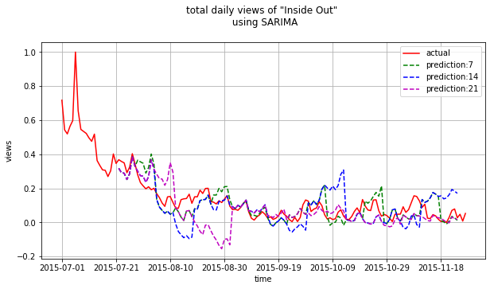

```python
dfsn_io = pd.read_csv('.\data\io\dfsn_io.csv',header=None,names=['date', 'views']).fillna(0)
predict7 = pd.read_csv('.\data\io\predict7.csv',header=None,names=['date', 'views']).fillna(0)
predict14 = pd.read_csv('.\data\io\predict14.csv',header=None,names=['date', 'views'] ).fillna(0)
predict21 = pd.read_csv('.\data\io\predict21.csv', header=None,names=['date', 'views']).fillna(0)
PlotARIMAPrediction(dfsn_io, "Inside Out")
```

Let's plot the RMSE for the predictions:

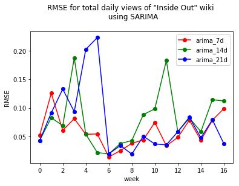

```python
PlotARIMA_RMSE(dfsn_io, predict7, predict14, predict21, "Inside Out")
```

The RMSE errors from prediction with different step sizes are as follows:

[figure not shown]

We run similar models for three other web pages:

Sanada Maru (japanese TV shows), Pretty Little Liars and William Shakespeare

and get the following results

[figure not shown]